# Exploratory data analysis of Mosquito Habitat Mapper

Gustavo Amador Fonseca C20451

2024-10-10

# Carga de datos

```r
# Cargando una librería para utilizar funciones específicas
library(leaflet)
library(readxl)
library(dplyr)
```

```r
library(ggplot2)

#Llamar datos
data_ori <- read_excel("C:/Users/AMADOR/OneDrive - Universidad de Costa Rica/ASISTENCIA/Fabio Sánchez/Análisis exploratorio/data/GLOBEMeasurementData-21594.xlsx")
View(data_ori)
print(data_ori)
```

```
## # A tibble: 43,810 × 41
##    organization_id org_name       site_id site_name latitude longitude elevation
##              <dbl> <chr>            <dbl> <chr>     <chr>    <chr>     <chr>
##  1        48594814 Abdullrahaman…  333864 40QFL597… 2270048  58554785  452.1
##  2        17725501 AEB-Escola       52145 22JGS466… -258366… -4853978  11.0
##  3        17725501 AEB-Escola       52142 22JGS466… -258357… -48539798 9.0
##  4        17725501 AEB-Escola      127044 23LJC844… -158196… -47946023 1098.0
##  5        17725501 AEB-Escola      127045 23LJC845… -158187… -47945077 1097.3
##  6        17725501 AEB-Escola      185498 25MBP601… -5926967 -35166921 39.5
##  7        55870117 Aek Ayothaya    153100 47PPR692… 14347203 100569012 6.8
##  8        55870117 Aek Ayothaya    153101 47PPR693… 14349005 100569951 8.5
##  9        10532743 Africa GLOBE …  132251 36NVF470… 0.197225 32523705  1201.5
## 10        10532743 Africa GLOBE …  132150 36NVF472… 0.197225 32525502  1191.0
## # ℹ 43,800 more rows
## # ℹ 34 more variables: measured_on <dttm>,
## #   `mosquito habitat mapper:mosquito habitat mapper id` <dbl>,
## #   `mosquito habitat mapper:data source` <chr>,
## #   `mosquito habitat mapper:userid` <dbl>,
## #   `mosquito habitat mapper:measured at` <chr>,
## #   `mosquito habitat mapper:water source type` <chr>, …
```

```r
Mosquito_Habitat_Mapper_GLOBE_Measurement <- read_excel("C:/Users/AMADOR/OneDrive - Universidad de Costa Rica/ASISTENCIA/Fabio Sánchez/Climate_Project/data/Mosquito_Habitat_Mapper_GLOBE_Measurement.xlsx",
    sheet = "Data")
View(Mosquito_Habitat_Mapper_GLOBE_Measurement)
```

# Limpieza de datos

## Estimación de valores coordenadas

```r
# Cargando una librería para utilizar funciones específicas

#Arreglar columnas latitud y longitud a escala
data_clea <- Mosquito_Habitat_Mapper_GLOBE_Measurement

#Eliminar puntos de cols
#data_clea$latitude <- gsub("\\.", "", data_clea$latitude)
#data_clea$longitude <- gsub("\\.", "", data_clea$longitude)

#Hacerlas numéricas
#data_clea$latitude <- as.numeric(data_clea$latitude)
#data_clea$longitude <- as.numeric(data_clea$longitude)
#data_clea$elevation <- as.numeric(data_clea$elevation)

#escalar columnas
#data_clea$latitude <- round(data_clea$latitude / 1e6, 6)
#data_clea$longitude <- round(data_clea$longitude / 1e6, 6)
```

## Renombrar clases de la columna `mosquito habitat mapper:water source`

```r
data_clea <- data_clea %>%
  mutate(`water_source` = recode(`water_source`,
                         "swamp or wetland" = "Pantano o humedal",
                         "can or bottle" = "Lata o botella",
                         "plant clumps (bamboo etc)" = "Grupo plantas",
                         "flower or plant pot/tray" = "Maceta",
                         "ditch" = "Zanja",
                         "tire" = "Neumático",
                         "other" = "Otro",
                         "cement, metal or plastic tank" = "Tanque",
                         "puddle, vehhicle or animal tracks" = "Charcos y huellas",
                         "dish or pot" = "Plato o olla",
                         "plant husk (areca, coconut etc)" = "Cáscara planta",
                         "trash container" = "Basurero",
                         "fountain or bird bath" = "Fuente",
                         "well or cistern" = "Pozo o cisterna",
                         "jar" = "Frasco",
                         "pond" = "Estanque",
                         "tree holes" = "Huecos en árboles",
                         "puddle or still water next to a creek, stream or river" = "Charca junto a río",
                         "reservoir" = "Reservorio",
                         "grill or outdoor appliance" = "Parrilla",
                         "discarded: other" = "Desecho: otro",
                         "animal shell (tortoise, mollusk etc)" = "Caparazón animal",
                         "pool" = "Piscina",
                         "animal trough or water bowl" = "Bebedero",
                         "estuary" = "Estuario",
                         "puddle, vehicle or animal tracks" = "Charcos y huellas",
                         "ovitrap" = "Ovitrap",
                         "rain gutter or other architectural feature" = "Canalón",
                         "lake" = "Lago",
                         "adult mosquito trap" = "Trampa mosquitos",
                         "old car or boat" = "Auto/barco viejo",
                         "public works - culvert, bridge, road" = "Obras públicas",
                         "bay or ocean" = "Bahía u océano",
                         "refrigerator drainage" = "Drenaje refrigerador"
))
```

## Asígnación de colores nuevas clases de la columna `mosquito habitat mapper:water source`

```r
# Definir los colores para cada clase usando códigos hexadecimales
colores <- c("Pantano o humedal" = "#1f77b4",  # blue
             "Lata o botella" = "#2ca02c",    # green
             "Grupo plantas" = "#d62728",     # red
             "Maceta" = "#ff7f0e",            # orange
             "Zanja" = "#9467bd",             # purple
             "Neumático" = "#8c564b",         # brown
             "Otro" = "#e377c2",              # pink
             "Tanque" = "#17becf",            # cyan
             "Charcos y huellas" = "#7f7f7f", # gray
             "Plato o olla" = "#bcbd22",      # yellow
             "Cáscara planta" = "#7f7f7f",    # gray
             "Basurero" = "#000000",          # black
             "Fuente" = "#000080",            # navy
             "Pozo o cisterna" = "#a0ff00",   # lime
             "Frasco" = "#ff7f50",            # coral
             "Estanque" = "#87cefa",          # lightblue
             "Huecos en árboles" = "#006400", # darkgreen
             "Charca junto a río" = "#008080",# teal
             "Reservorio" = "#fa8072",        # salmon
             "Parrilla" = "#ee82ee",          # violet
             "Desecho: otro" = "#ffd700",     # gold
             "Caparazón animal" = "#ff8c00",  # darkorange
             "Piscina" = "#dda0dd",           # plum
             "Bebedero" = "#f0e68c",          # khaki
             "Estuario" = "#483d8b",          # darkslateblue
             "Ovitrap" = "#90ee90",           # lightgreen
             "Canalón" = "#d3d3d3",           # lightgray
             "Lago" = "#da70d6",              # orchid
             "Trampa mosquitos" = "#ff4500",  # red3
             "Auto/barco viejo" = "#d2b48c",  # tan
             "Obras públicas" = "#a0522d",    # sienna
             "Bahía u océano" = "#87ceeb",     # skyblue
             "Drenaje refrigerador" = "#32cd32" # limegreen
)
```

```r
data_clea <- data_clea %>%
  mutate(water_source_type = recode(water_source_type,
                         "still: lake/pond/swamp" = "Pantano/humedal",
                         "container: natural" = "Cont.natural",
                         "container: artificial" = "Cont. artificial",
                         "flowing: still water found next to river or stream" = "Agua estancada de rio/arroyo", ))
```

# Análisis exploratorio de variables

## Gráfica de coordenadas en mapa mundial

```r
# Asegúrate de que las columnas de longitud y latitud son numéricas
data_clea$longitude <- as.numeric(data_clea$longitude)
data_clea$latitude <- as.numeric(data_clea$latitude)

# Crear un mapa interactivo
leaflet(data_clea) %>%
  addTiles() %>%  # Mapa base
  addCircles(
    lng = ~longitude,
    lat = ~latitude,
    color = "blue",  # Color de los círculos
    radius = 50,  # Ajusta el tamaño del círculo según sea necesario
    fillOpacity = 0.5,
    stroke = FALSE
  ) %>%
  addLegend("bottomright",
            pal = colorNumeric(palette = "blue", domain = data_clea$longitude),  # Usa valores de longitud como dominio
            values = data_clea$longitude,  # Usa los mismos valores para la leyenda
            title = "Puntos")
```

[interactive chart not shown]

Al observar los datos presentados, se aprecia cierta irregularidad, especialmente porque algunos registros aparecen ubicados en medio del mar, lo cual no es consistente con la lógica esperada. Según el documento de recolección de datos, las coordenadas y la altitud son registradas automáticamente por el dispositivo móvil que envía la información, lo que debería minimizar significativamente estos errores. Sin embargo, en el proceso de consolidación de la base de datos, se han identificado problemas relacionados con los decimales: algunos registros tienen más o menos dígitos y no presentan un separador decimal claro, lo cual genera interpretaciones erróneas de la información.

## Historgrama de la variable Elevación `elevation`

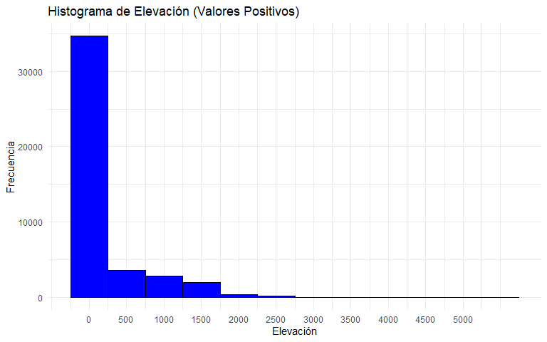

Se puede apreciar que la mayoría de los registros presentan una elevación entre los 0m y 500m de elevación, no obstante estos datos al igual que las coordenadas, al ser numéricos pueden presentar problemas con el separador decimal.

## Histograma de la variable tipo de fuente de agua `mosquito habitat mapper:water source type`

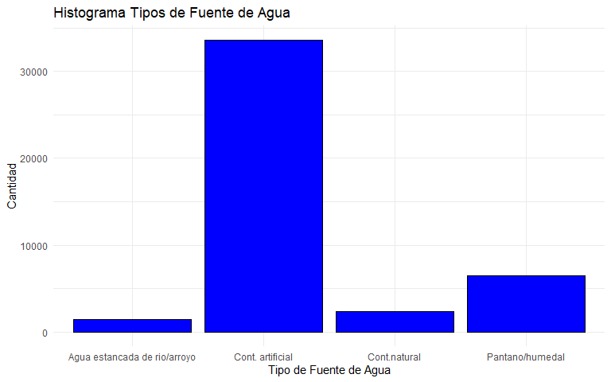

```
## numeric(0)
```

Se puede observar que en una gran mayoría, los reportes de mosquitos avistados (en sus distintas etapas de vida) fue en contenedores artificiales representando un 76,6% de las observaciones registradas.

## Histograma de la variable fuente de agua `mosquito habitat mapper:water source`

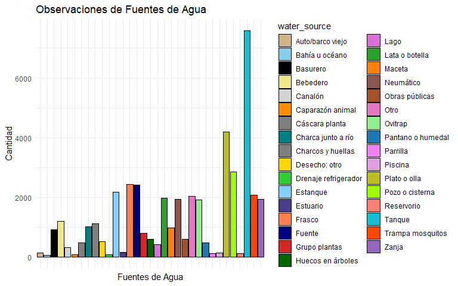

El histograma que observamos ilustra de manera clara la distribución de los tipos de fuentes de agua donde se detectaron mosquitos en alguna de sus etapas de vida, destacando cómo las fuentes artificiales continúan siendo las más comunes como hábitat de estos insectos dentro de las observaciones.

## Gráfico de barra sobre la variable pupas de mosquito `mosquito habitat mapper:mosquito pupae`

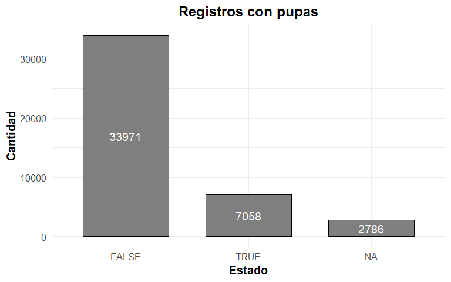

## Gráfico de barra sobre la variable huevos de mosquito `mosquito habitat mapper:mosquito eggs`

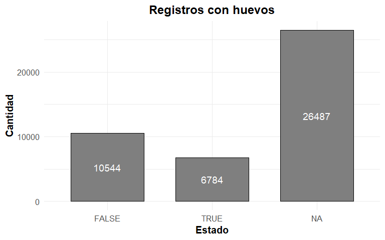

## Gráfico de barra sobre la variable mosquitos adultos `mosquito_adults`

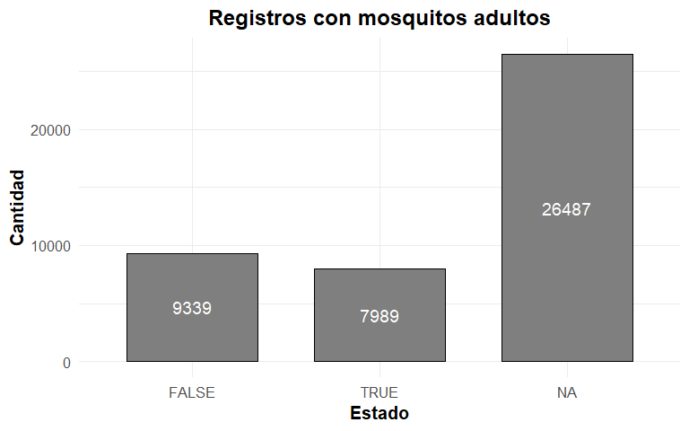

## Histograma de la variables género y clase de mosquitos `mosquito habitat mapper:species` `mosquito habitat mapper:species`

### Histograma con todos los registros

[figure not shown]

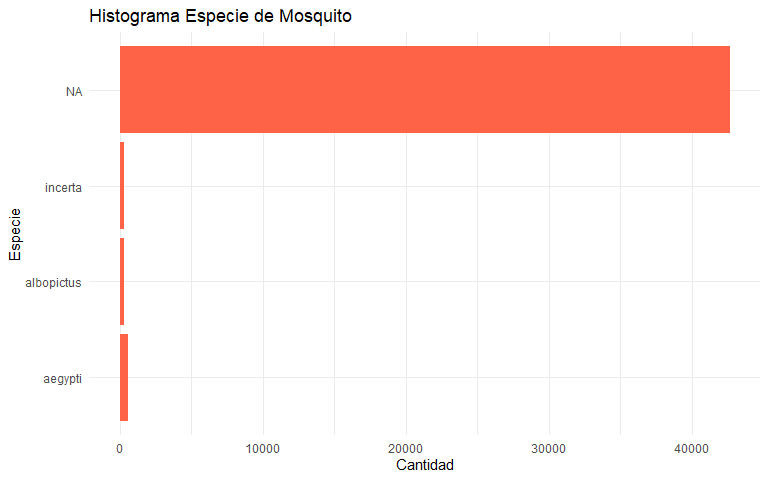

### Histograma excluyendo los registros vacíos (NA)

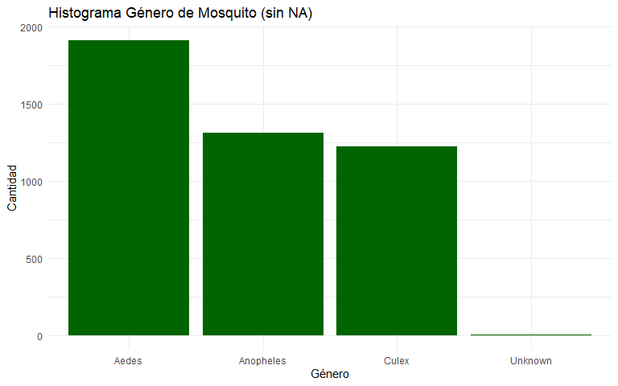

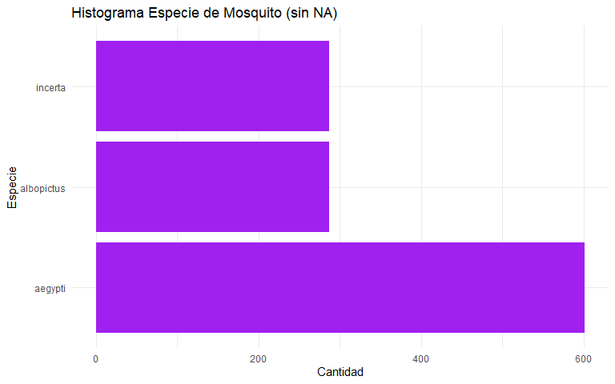

# Correlaciones con género y especie

## Prueba de Independencia con Chi cuadrado entre género y fuentes de agua

Se comparando la variable “género” con la variable “fuente de agua”. Dado que la columna de “fuente de agua” tiene muchas categorías (diferentes tipos de fuentes), para simplificar el análisis, utilizas un enfoque de tipo bootstrap donde seleccionas aleatoriamente 5 clases de la columna “fuente de agua” en cada simulación. Luego, realizas la prueba de independencia (chi-cuadrado o Fisher) con esas clases seleccionadas.

Como hipótesis nula ($H_0$) se considera indipendencia entre las variables con un nivel de significarncia de 5% $(\alpha =0.05$.

```r
set.seed(123)  # Fijar la semilla para reproducibilidad
n_simulaciones <- 20  # Número de simulaciones
n_clases <- 5  # Número de clases a seleccionar aleatoriamente en cada simulación
p_valores <- numeric(n_simulaciones)  # Vector para almacenar los p-valores

for (i in 1:n_simulaciones) {
  # Seleccionar aleatoriamente 5 clases de la columna 'fuente de agua'
  clases_aleatorias <- sample(unique(data_clea$water_source), n_clases)

  # Filtrar el data frame con las clases seleccionadas
  datos_filtrados <- data_clea %>%
    filter(water_source %in% clases_aleatorias)

  # Crear tabla de contingencia entre 'género' y 'fuente de agua'
  tabla_contingencia <- table(datos_filtrados$genus, datos_filtrados$water_source)

  # Usar prueba chi-cuadrado o prueba exacta de Fisher dependiendo de los conteos
  if (min(tabla_contingencia) < 5) {
    # Usar prueba exacta de Fisher con simulación Monte Carlo si hay conteos bajos
    resultado_prueba <- fisher.test(tabla_contingencia, simulate.p.value = TRUE, B = 10000)
  } else {
    # Usar prueba chi-cuadrado si los conteos son suficientes
    resultado_prueba <- chisq.test(tabla_contingencia)
  }

  # Almacenar el p-valor en el vector de p-valores
  p_valores[i] <- resultado_prueba$p.value
}

# Imprimir los p-valores de las 20 simulaciones
print(p_valores)
```

```
##  [1] 9.999000e-05 1.711829e-01 1.999800e-04 9.999000e-05 9.999000e-05
##  [6] 9.999000e-05 9.999000e-05 9.999000e-05 4.499550e-02 9.999000e-05
## [11] 5.647004e-12 7.015105e-09 9.999000e-05 2.799720e-03 3.999600e-04
## [16] 9.999000e-05 2.999700e-04 9.999000e-05 2.999700e-04 9.999000e-05
```

```r
# Imprimir el promedio de los p-valores
print(paste("El promedio de p-valor obtenidos en las 20 pruebas es:", mean(p_valores)))
```

```
## [1] "El promedio de p-valor obtenidos en las 20 pruebas es: 0.0110638939616765"
```

Dado que la mayoría de los p-valores obtenidos en las 20 simulaciones son extremadamente bajos (muchos cercanos a 0.00009999). Esto sugiere que en la mayoría de las corridas hay suficiente evidencia para rechazar la hipótesis nula de independencia entre el género del mosquito y las fuentes de agua seleccionadas.

## Prueba de Independencia con Chi cuadrado entre género y tipos de fuentes de agua

Se realizó una comparación entre la variable “género” y la variable “tipo de fuente de agua”. A diferencia del análisis anterior, en esta prueba se consideraron todas las categorías presentes en la columna “tipo de fuente de agua” sin realizar selecciones aleatorias. Se utilizó la prueba de independencia de chi-cuadrado para determinar si existe una relación significativa entre el género de los mosquitos y los diferentes tipos de fuentes de agua observados.

Como hipótesis nula ($H_0$), se asumió que las variables son independientes, es decir, que no hay relación entre el género del mosquito y el tipo de fuente de agua. El nivel de significancia utilizado fue del 5% ($\alpha = 0.05$).

```r
# Crear tabla de contingencia entre genus y water source type
tabla_contin <- table(data_clea$genus, data_clea$water_source_type)

# Usar la prueba de chi-cuadrado
resultado_test <- chisq.test(tabla_contin)

# Imprimir los resultados de la prueba chi-cuadrado
print(resultado_test)
```

```
##
##  Pearson's Chi-squared test
##
## data:  tabla_contin
## X-squared = 41.533, df = 9, p-value = 4e-06
```

El p-valor obtenido en la prueba de chi-cuadrado es 4e-06, que está muy por debajo del nivel de significancia típico $(\alpha = 0.05)$. Esto indica que existe una relación significativa entre el género del mosquito y los diferentes tipos de fuentes de agua observados. Por lo tanto, se rechaza la hipótesis nula de independencia, lo que sugiere que el tipo de fuente de agua está relacionado con el género del mosquito.

## Prueba de V-cramer entre las varibles

```r
# Filtrar datos donde el género sean los principales
data_selected <- data_clea %>% filter(genus %in% c("Anopheles", "Culex", "Aedes"))

# Seleccionar columnas relevantes para el análisis
relevant_columns <- c(
  "water_source",
  "water_source_type",
  "larvae_count",
  "elevation"
)
data_selected_relevant <- data_selected %>% select(all_of(relevant_columns)) %>% na.omit()

results_generos <- list()
for (column in c("water_source", "water_source_type")) {
  contingency_table <- table(data_selected$genus, data_selected[[column]])
  chi_result <- chisq.test(contingency_table)
  results_generos[[column]] <- list(chi2 = chi_result$statistic, p_value = chi_result$p.value)
}

chi_squared <- chi_result$statistic
N <- sum(contingency_table)

# Obtener el número de filas y columnas de la tabla de contingencia
n_filas <- nrow(contingency_table)
n_columnas <- ncol(contingency_table)

k <- min(n_filas, n_columnas)

# Calcular V de Cramer
V_cramer <- sqrt(chi_squared / (N * (k - 1)))

# Imprimir V de Cramer con un mensaje claro
print(paste("V de Cramer:", V_cramer))
```

```
## [1] "V de Cramer: 0.0679760508214442"
```

Con el valor de V de Cramer: 0.0679760508214442. Asociación muy débil: El valor de V de Cramer está cerca de cero, lo cual indica que, aunque haya una asociación significativa entre el género del mosquito y las características de la fuente de agua, la fuerza de esta asociación es muy débil. En otras palabras, el género del mosquito tiene muy poca influencia sobre el tipo de fuente de agua o el tipo de fuente de agua tiene muy poco efecto en determinar el género del mosquito.

# Correlación entre la presencia de aedes y variables geográficas

## Calcular la correlacion de Pearson del genero aedes con las variables coordenadas y elevacion

```r
#Crear un DataFrame con las columnas de interes
df_geografico <- data.frame(genero = data_clea$genus, latitud = data_clea$latitude, longitud = data_clea$longitude, elevacion = data_clea$elevation)

#Imputar filas con NA en la columna genero
df_geografico_sin_na <- df_geografico %>% filter(!is.na(genero))

#columna genero a una variable binaria
df_geografico_sin_na$aedes <- ifelse(df_geografico_sin_na$genero == "Aedes", 1, 0)

#la correlacion de Pearson entre Aedes y las coordenadas (latitud y longitud) conjuntamente
df_geografico_sin_na$coord_pair <- df_geografico_sin_na$latitud * df_geografico_sin_na$longitud
cor_coord_pair <- cor(df_geografico_sin_na$aedes, df_geografico_sin_na$coord_pair, use = "complete.obs")

#la correlacion de Pearson entre Aedes y la elevacion
cor_elevacion <- cor(df_geografico_sin_na$aedes, df_geografico_sin_na$elevacion, use = "complete.obs")

print(paste("Correlacion entre Aedes y coordenadas (latitud * longitud):", cor_coord_pair))
```

```
## [1] "Correlacion entre Aedes y coordenadas (latitud * longitud): 0.0140796343526614"
```

```r
print(paste("Correlacion entre Aedes y elevacion:", cor_elevacion))
```

```
## [1] "Correlacion entre Aedes y elevacion: -0.00483002167869528"
```

Ambas correlaciones muestran que las variables latitud, longitud (en combinación) y elevación no están fuertemente relacionadas con la presencia de Aedes, lo cual sugiere que otros factores pueden ser más importantes para explicar su distribución.

## Modelo de regresion logistica para la probabilidad de presencia de Aedes y coordenadas

```r
modelo_aedes_coords <- glm(aedes ~ latitud + longitud, data = df_geografico_sin_na, family = binomial)
summary(modelo_aedes_coords)
```

```
##
## Call:
## glm(formula = aedes ~ latitud + longitud, family = binomial,
##     data = df_geografico_sin_na)
##
## Coefficients:
##               Estimate Std. Error z value Pr(>|z|)
## (Intercept) -0.1386098  0.0381392  -3.634 0.000279 ***
## latitud     -0.0151202  0.0023065  -6.555 5.55e-11 ***
## longitud     0.0010593  0.0004173   2.539 0.011131 *
## ---
## Signif. codes:  0 '***' 0.001 '**' 0.01 '*' 0.05 '.' 0.1 ' ' 1
##
## (Dispersion parameter for binomial family taken to be 1)
##
##     Null deviance: 6068.8  on 4441  degrees of freedom
## Residual deviance: 6021.4  on 4439  degrees of freedom
## AIC: 6027.4
##
## Number of Fisher Scoring iterations: 4
```

Latitud y longitud tienen una influencia significativa sobre la presencia de Aedes. La latitud tiene un impacto negativo, lo que sugiere que Aedes es más probable que se encuentre en ciertas áreas más al sur (dependiendo del sistema de referencia). La longitud tiene un impacto positivo, aunque menos pronunciado.